# morphology-analysis_final

### PCA analysis

In this analysis, I will compare the principle components after centering and scaling the data. A PCA analysis will help us determine what aspects of morphology influence the variation in our data the most without worrying about differences in scales/measurements. Currently, data consists of **116 Sailfin and 186 Amazon**.

*Variable chart:*

- D: dorsal ray count
- P1: left pectoral ray count
- P2.L: left pelvic rays
- P2.R: right pelvic rays
- A: anal rays
- P1.R: right pectoral ray count
- LLSC: lateral line scale count
- SALL: scales above lateral line
- SBLL: scales below lateral line
- SBDF: scales before dorsal fin
- TL: total length
- SL: standard length
- BD: body depth
- CPD: caudal peduncle depth
- CPL: caudal peduncle length
- PreDL: pre-dorsal length
- DbL: dorsal base length
- HL/HW/HD: head length/width/depth
- SnL: snout length
- OL: ocular length
- summary of PCs

```
## Importance of components:
##                           PC1    PC2     PC3     PC4     PC5    PC6     PC7
## Standard deviation     3.1755 1.6254 1.24229 1.17377 1.00433 0.9950 0.95226
## Proportion of Variance 0.4583 0.1201 0.07015 0.06262 0.04585 0.0450 0.04122
## Cumulative Proportion  0.4583 0.5784 0.64858 0.71121 0.75706 0.8021 0.84328
##                            PC8     PC9    PC10    PC11    PC12    PC13    PC14
## Standard deviation     0.87232 0.76811 0.69398 0.61674 0.53375 0.51888 0.45108
## Proportion of Variance 0.03459 0.02682 0.02189 0.01729 0.01295 0.01224 0.00925
## Cumulative Proportion  0.87787 0.90468 0.92658 0.94386 0.95681 0.96905 0.97830
##                           PC15    PC16    PC17    PC18    PC19    PC20    PC21
## Standard deviation     0.36407 0.30647 0.25299 0.23051 0.22109 0.20197 0.18889
## Proportion of Variance 0.00602 0.00427 0.00291 0.00242 0.00222 0.00185 0.00162
## Cumulative Proportion  0.98433 0.98859 0.99150 0.99392 0.99614 0.99800 0.99962
##                           PC22
## Standard deviation     0.09179
## Proportion of Variance 0.00038
## Cumulative Proportion  1.00000
```

```
##                PC1           PC2          PC3           PC4          PC5
## D     -0.029756680  0.5196321794  0.033745852  0.2794334345 -0.054409185
## P1    -0.017022339 -0.3919716290 -0.025085243  0.4225842207  0.064089952
## P2.L  -0.011040473  0.0694169134 -0.666273458  0.1880205761  0.134312075
## P2.R   0.026368730  0.0287321007 -0.695427541 -0.0583462065 -0.052317407
## A     -0.002570935 -0.0640389971  0.137124347  0.4962655444 -0.324131689
## P1.R  -0.028096901 -0.4121170099  0.038987974  0.3372127153  0.029076582
## LLSC  -0.086559168  0.2309989210  0.172621552  0.2495803383  0.426620028
## SALL  -0.049450371 -0.0231083533  0.121098689 -0.4423922512  0.095749667
## SBLL  -0.060869337  0.1406631450  0.028770922  0.1197204381  0.741232549
## SBDF  -0.009117326 -0.4267933901 -0.026331101 -0.1659314683  0.318091743
## TL    -0.305156136 -0.0471932717 -0.011527223  0.0004412165 -0.025901326
## SL    -0.309549497 -0.0600821967 -0.017233613  0.0028955955 -0.020676806
## BD    -0.301191644  0.0896466527 -0.007647997 -0.0129310190 -0.023995753
## CPD   -0.306394598  0.0004864882 -0.022796700 -0.0106990279 -0.048887793
## CPL   -0.298972243 -0.0748577558  0.004141968  0.0221483747 -0.012786358
## PreDL -0.288931064 -0.1924903603 -0.018488205 -0.0521639134  0.003770775
## DbL   -0.257540909  0.2770169091  0.027003206  0.0963547449 -0.074129571
## HL    -0.268520294 -0.0502249706 -0.009178296  0.0552435956  0.011140495
## HD    -0.301416722  0.0155754555 -0.043758991 -0.0348256569 -0.026849459
## HW    -0.301061670 -0.0256037930 -0.015347950 -0.0993410395 -0.008938222
## SnL   -0.199627600  0.0632754482 -0.005763713 -0.1315386738 -0.117157948
## OL    -0.278051990 -0.0151279993  0.004556287  0.0224111085 -0.008931626
```

```
##          Length Class    Mode
## loadings 484    loadings numeric
## rotmat   484    -none-   numeric
```

- visualization of PCA

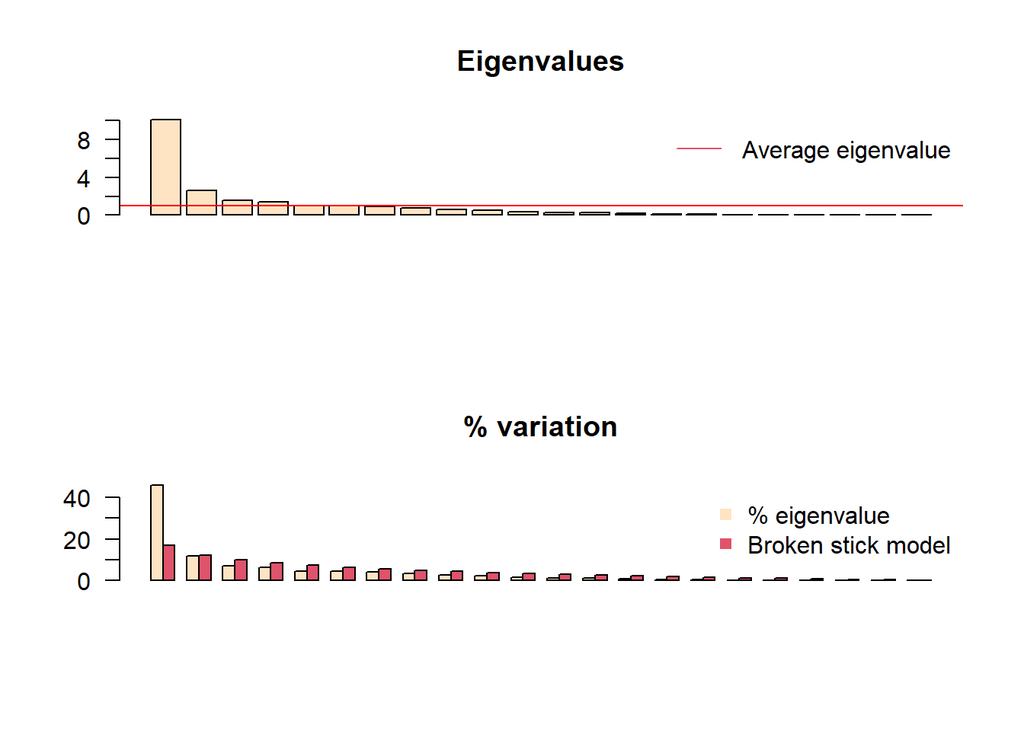

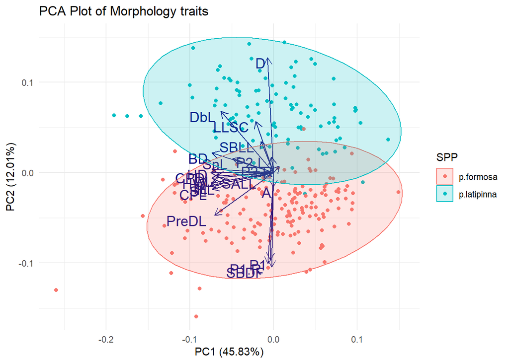

```
## Too few points to calculate an ellipse
```

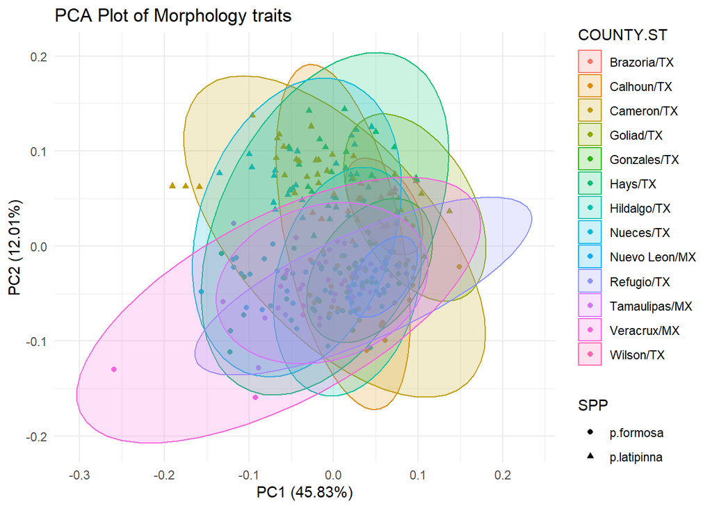

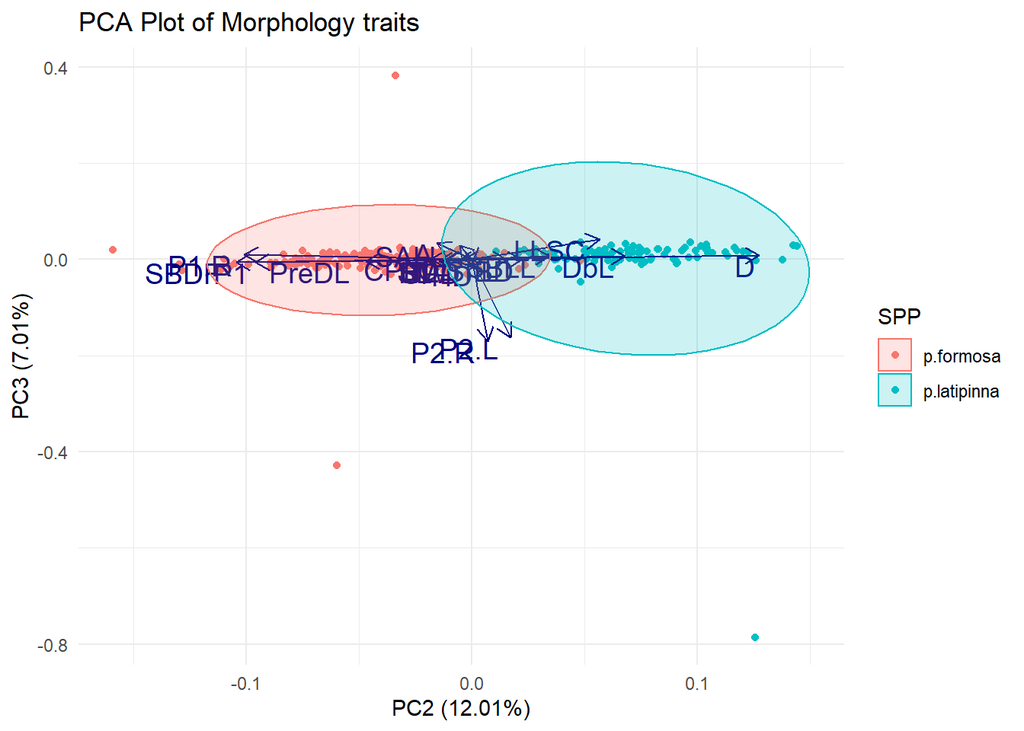

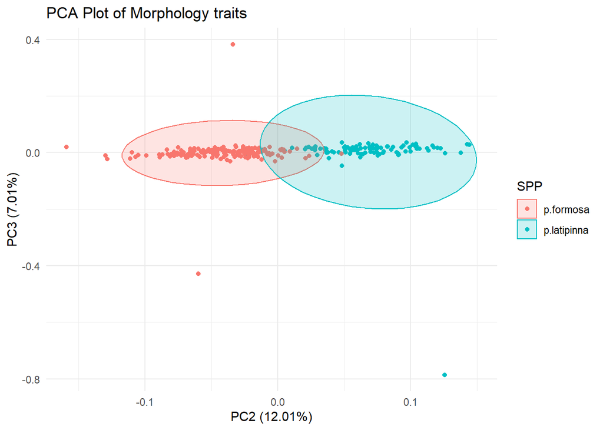

```
## Too few points to calculate an ellipse
```

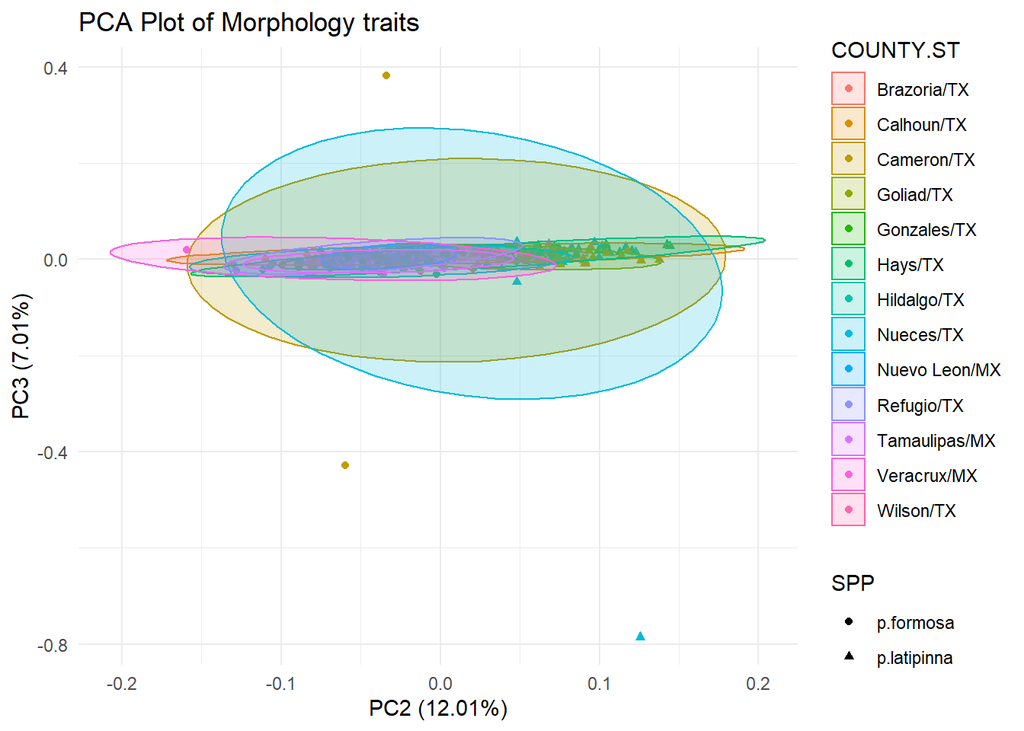

*Variable chart:*

- D: dorsal ray count
- P1: left pectoral ray count
- P2.L: left pelvic rays
- P2.R: right pelvic rays
- A: anal rays
- P1.R: right pectoral ray count
- LLSC: lateral line scale count
- SALL: scales above lateral line
- SBLL: scales below lateral line
- SBDF: scales before dorsal fin
- TL: total length
- SL: standard length
- BD: body depth
- CPD: caudal peduncle depth
- CPL: caudal peduncle length
- PreDL: pre-dorsal length
- DbL: dorsal base length
- HL/HW/HD: head length/width/depth
- SnL: snout length
- OL: ocular length

### T and F tests (body size corrected)

F tests on residuals doesn’t make much sense; the residuals themselves are representative of the variation present, as they are the distance from the mean. Therefore, F tests on residuals is like variance of the variance. Instead, I have to do a t-test on the absolute value of the residuals. In this sense, we want to see if the mean of the absolute residuals is higher or lower for asexual species–is the average amount of variation higher or lower for this trait? What I need to do is first compare the absolute value of the residuals using a t-test; if the r2 for the regression plot of SL vs trait is not significant, than this suggests it does not vary with body size. I can then do the regular F tests on those traits.

So: 1. Plot regression of trait by SL for both species and all traits. Get r2 values and their associated p values. 2. Get the absolute value of the residual scores. 3. Plot the mean absolute values of the residuals for both species (with raw data) for each trait. 4. Run a t-test for the absolute values of the residuals for all traits. 5. Backtrack: if r2 is not significant from (1), then use F tests on raw data.

#### Calculated residuals

I will now use residuals to account for body size in each trait, and compare the variance for each species. Again, the first round will take the raw residuals, and the second round with use the absolute value of the raw residuals.

##### Regressions

- STEP ONE: plot trait vs body size

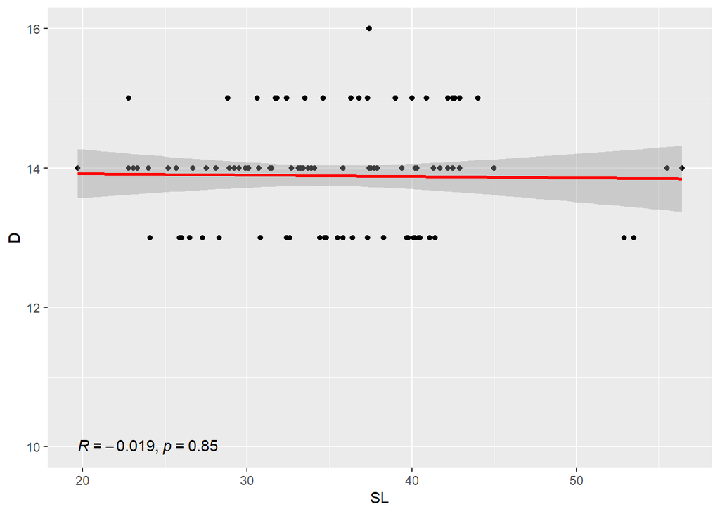

```r
library(ggplot2)
library(ggpubr)

lat1 <- lat[complete.cases(lat[, 10:31]),]
form1 <- form[complete.cases(form[, 10:31]),]

#previously performed regression with SL on y and trait on x; corrected the code below to have SL on x and trait on y

reg.lat.D1 <- lm(lat1$D ~ lat1$SL)
reg.lat.D1.plot <- ggplot(lat1, aes(x = SL, y = D)) +
  geom_point() +
  stat_smooth(method = "lm", col = "red") +
  stat_cor(label.y = 10)
reg.lat.D1.plot
```

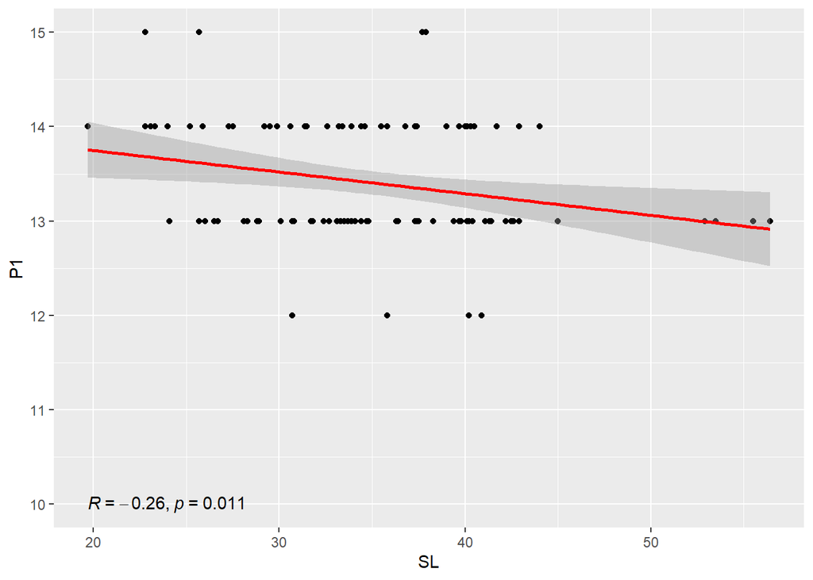

```r
reg.lat.P11 <- lm(lat1$P1 ~ lat1$SL)
reg.lat.P11.plot <- ggplot(lat1, aes(x = SL, y = P1)) +
  geom_point() +
  stat_smooth(method = "lm", col = "red") +
  stat_cor(label.y = 10)
reg.lat.P11.plot
```

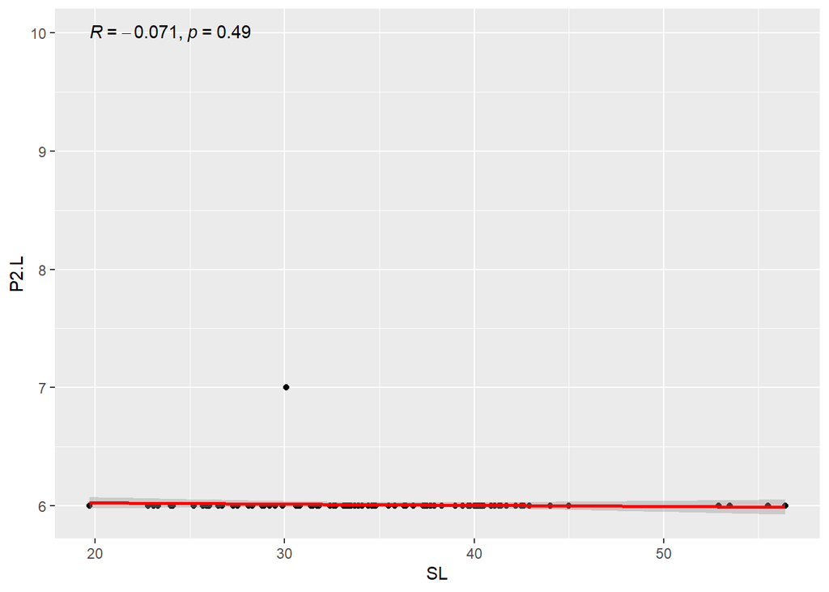

```r
reg.lat.P2.L1 <- lm(lat1$P2.L ~ lat1$SL)
reg.lat.P2.L1.plot <- ggplot(lat1, aes(x = SL, y = P2.L)) +
  geom_point() +
  stat_smooth(method = "lm", col = "red") +
  stat_cor(label.y = 10)
reg.lat.P2.L1.plot
```

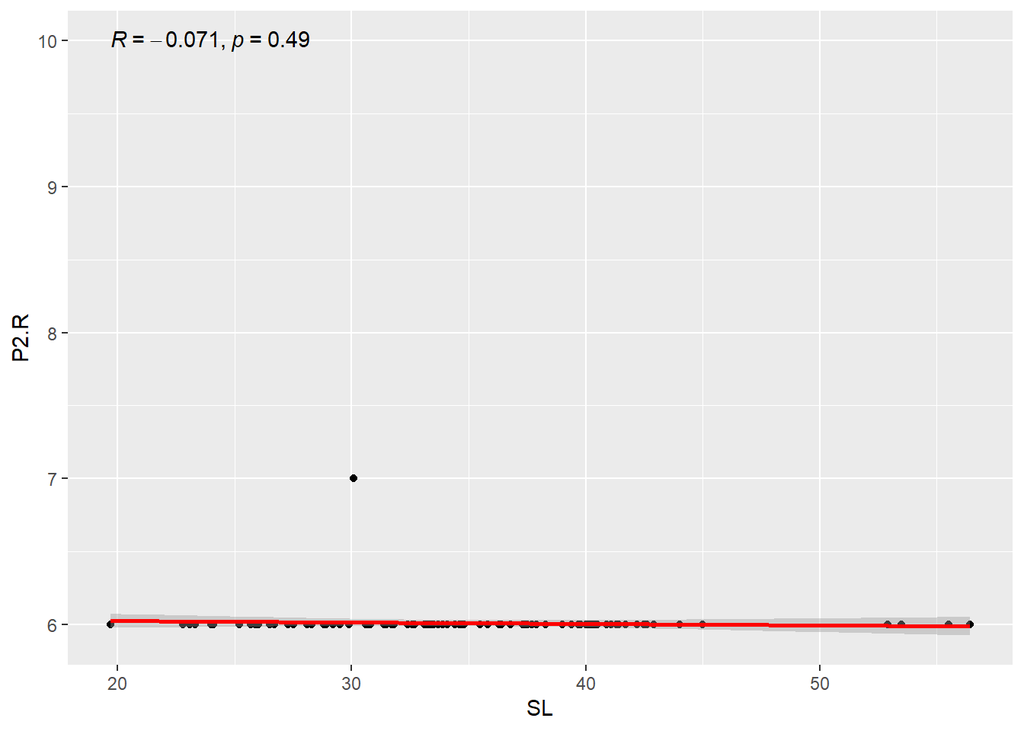

```r
reg.lat.P2.R1 <- lm(lat1$P2.R ~ lat1$SL)
reg.lat.P2.R1.plot <- ggplot(lat1, aes(x = SL, y = P2.R)) +
  geom_point() +
  stat_smooth(method = "lm", col = "red") +
  stat_cor(label.y = 10)
reg.lat.P2.R1.plot
```

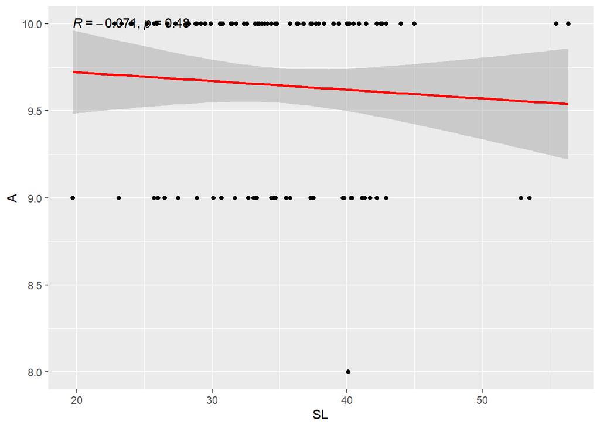

```r
reg.lat.A1 <- lm(lat1$A ~ lat1$SL)
reg.lat.A1.plot <- ggplot(lat1, aes(x = SL, y = A)) +
  geom_point() +
  stat_smooth(method = "lm", col = "red") +
  stat_cor(label.y = 10)
reg.lat.A1.plot
```

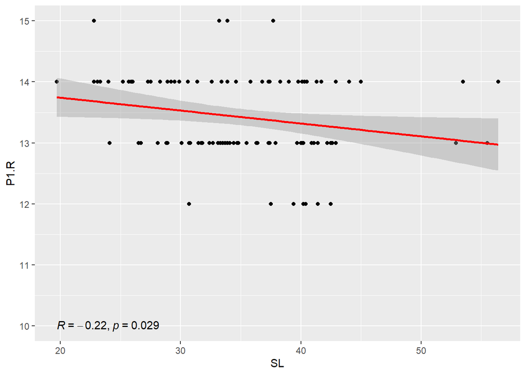

```r
reg.lat.P1.R1 <- lm(lat1$P1.R ~ lat1$SL)
reg.lat.P1.R1.plot <- ggplot(lat1, aes(x = SL, y = P1.R)) +
  geom_point() +
  stat_smooth(method = "lm", col = "red") +
  stat_cor(label.y = 10)
reg.lat.P1.R1.plot
```

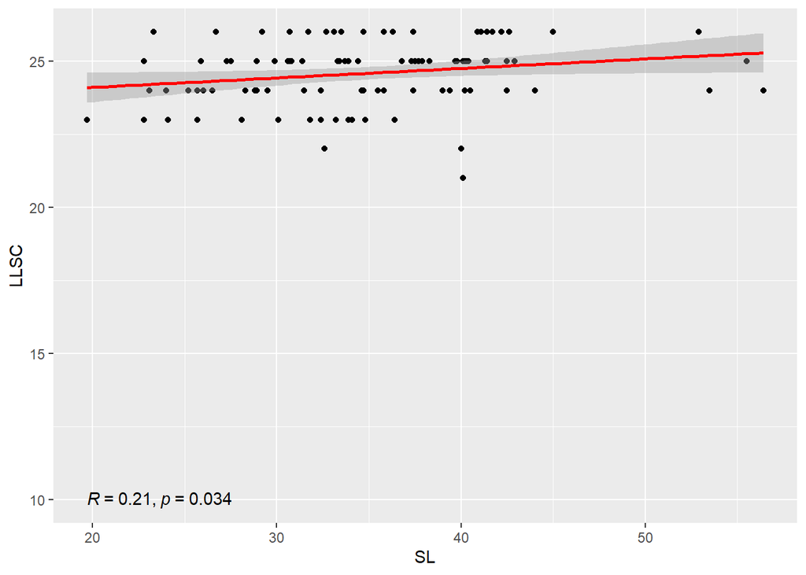

```r
reg.lat.LLSC1 <- lm(lat1$LLSC ~ lat1$SL)
reg.lat.LLSC1.plot <- ggplot(lat1, aes(x = SL, y = LLSC)) +
  geom_point() +
  stat_smooth(method = "lm", col = "red") +
  stat_cor(label.y = 10)
reg.lat.LLSC1.plot
```

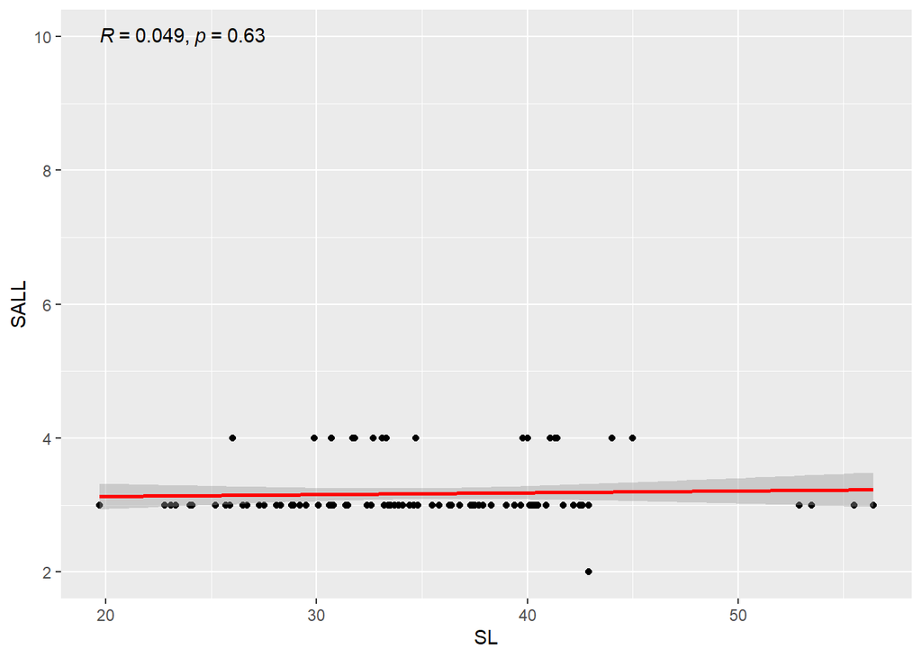

```r
reg.lat.SALL1 <- lm(lat1$SALL ~ lat1$SL)
reg.lat.SALL1.plot <- ggplot(lat1, aes(x = SL, y = SALL)) +
  geom_point() +
  stat_smooth(method = "lm", col = "red") +
  stat_cor(label.y = 10)
reg.lat.SALL1.plot
```

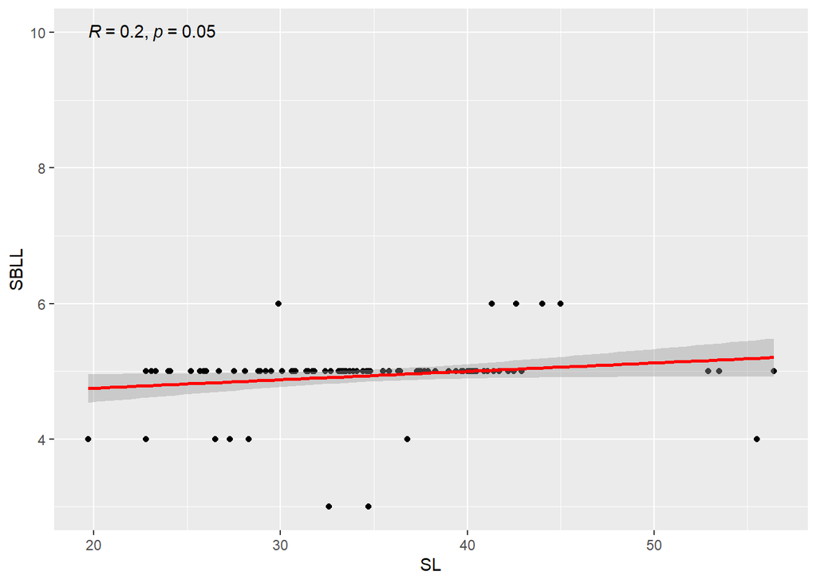

```r
reg.lat.SBLL1 <- lm(lat1$SBLL ~ lat1$SL)
reg.lat.SBLL1.plot <- ggplot(lat1, aes(x = SL, y = SBLL)) +
  geom_point() +
  stat_smooth(method = "lm", col = "red") +
  stat_cor(label.y = 10)
reg.lat.SBLL1.plot
```

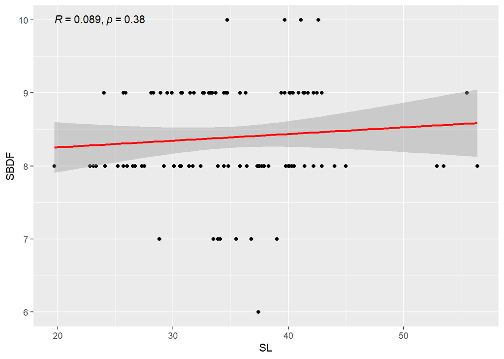

```r
reg.lat.SBDF1 <- lm(lat1$SBDF ~ lat1$SL)
reg.lat.SBDF1.plot <- ggplot(lat1, aes(x = SL, y = SBDF)) +
  geom_point() +
  stat_smooth(method = "lm", col = "red") +
  stat_cor(label.y = 10)
reg.lat.SBDF1.plot
```

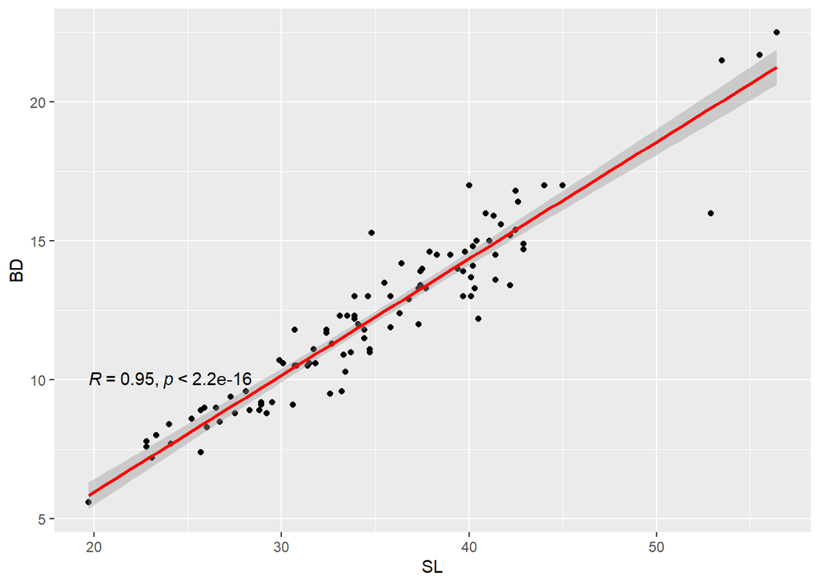

```r
reg.lat.BD1 <- lm(lat1$BD ~ lat1$SL)
reg.lat.BD1.plot <- ggplot(lat1, aes(x = SL, y = BD)) +
  geom_point() +
  stat_smooth(method = "lm", col = "red") +
  stat_cor(label.y = 10)
reg.lat.BD1.plot
```

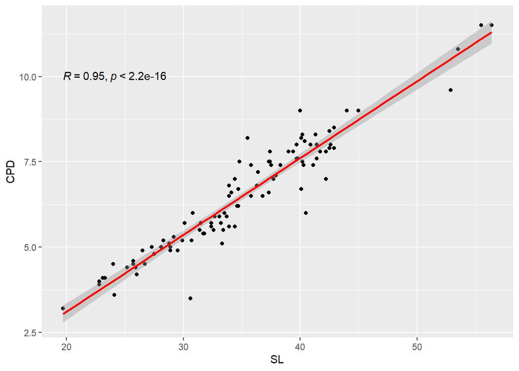

```r
reg.lat.CPD1 <- lm(lat1$CPD ~ lat1$SL)
reg.lat.CPD1.plot <- ggplot(lat1, aes(x = SL, y = CPD)) +
  geom_point() +
  stat_smooth(method = "lm", col = "red") +
  stat_cor(label.y = 10)
reg.lat.CPD1.plot
```

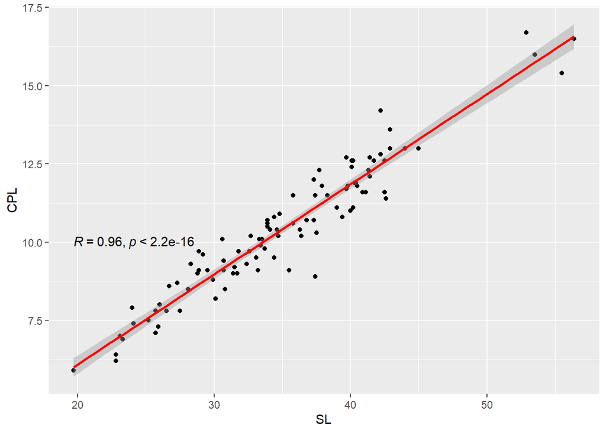

```r
reg.lat.CPL1 <- lm(lat1$CPL ~ lat1$SL)
reg.lat.CPL1.plot <- ggplot(lat1, aes(x = SL, y = CPL)) +
  geom_point() +
  stat_smooth(method = "lm", col = "red") +
  stat_cor(label.y = 10)
reg.lat.CPL1.plot
```

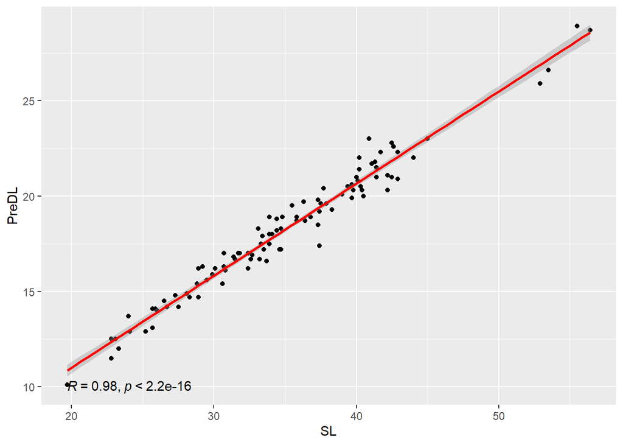

```r
reg.lat.PreDL1 <- lm(lat1$PreDL ~ lat1$SL)
reg.lat.PreDL1.plot <- ggplot(lat1, aes(x = SL, y = PreDL)) +
  geom_point() +
  stat_smooth(method = "lm", col = "red") +
  stat_cor(label.y = 10)
reg.lat.PreDL1.plot
```

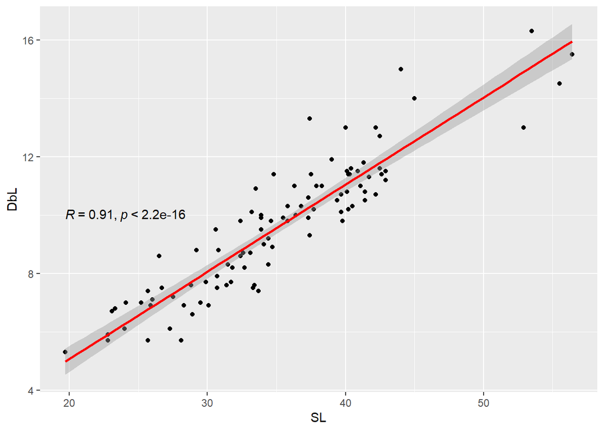

```r
reg.lat.DbL1 <- lm(lat1$DbL ~ lat1$SL)
reg.lat.DbL1.plot <- ggplot(lat1, aes(x = SL, y = DbL)) +
  geom_point() +
  stat_smooth(method = "lm", col = "red") +
  stat_cor(label.y = 10)
reg.lat.DbL1.plot
```

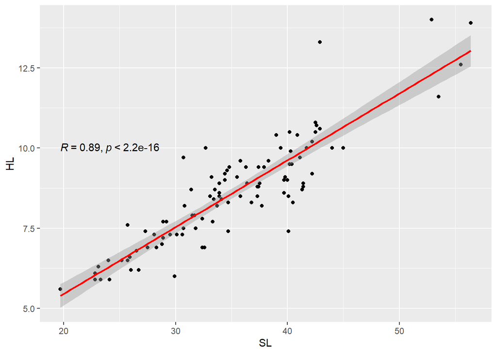

```r
reg.lat.HL1 <- lm(lat1$HL ~ lat1$SL)
reg.lat.HL1.plot <- ggplot(lat1, aes(x = SL, y = HL)) +
  geom_point() +
  stat_smooth(method = "lm", col = "red") +
  stat_cor(label.y = 10)
reg.lat.HL1.plot
```

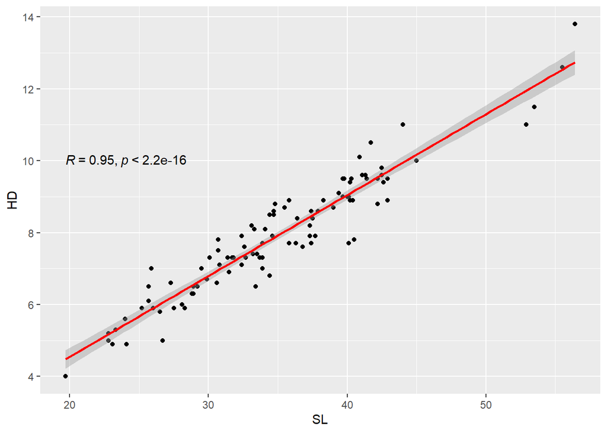

```r
reg.lat.HD1 <- lm(lat1$HD ~ lat1$SL)
reg.lat.HD1.plot <- ggplot(lat1, aes(x = SL, y = HD)) +
  geom_point() +
  stat_smooth(method = "lm", col = "red") +
  stat_cor(label.y = 10)
reg.lat.HD1.plot
```

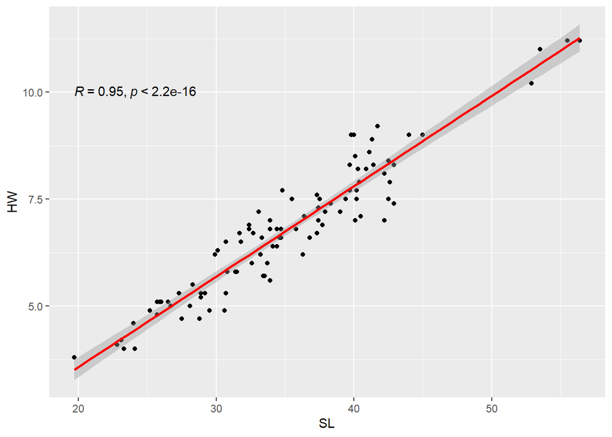

```r
reg.lat.HW1 <- lm(lat1$HW ~ lat1$SL)
reg.lat.HW1.plot <- ggplot(lat1, aes(x = SL, y = HW)) +
  geom_point() +
  stat_smooth(method = "lm", col = "red") +
  stat_cor(label.y = 10)
reg.lat.HW1.plot
```

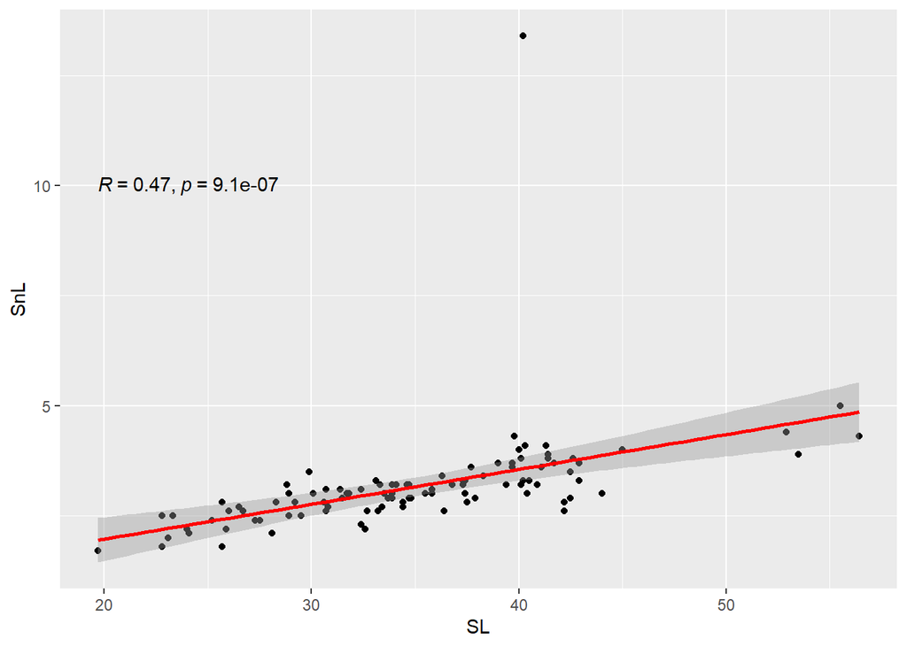

```r
reg.lat.SnL1 <- lm(lat1$SnL ~ lat1$SL)
reg.lat.SnL1.plot <- ggplot(lat1, aes(x = SL, y = SnL)) +
  geom_point() +
  stat_smooth(method = "lm", col = "red") +
  stat_cor(label.y = 10)
reg.lat.SnL1.plot
```

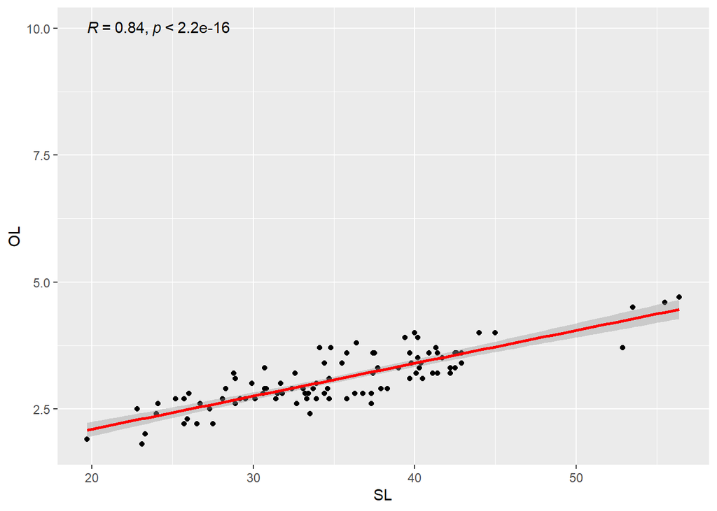

```r
reg.lat.OL1 <- lm(lat1$OL ~ lat1$SL)
reg.lat.OL1.plot <- ggplot(lat1, aes(x = SL, y = OL)) +
  geom_point() +
  stat_smooth(method = "lm", col = "red") +
  stat_cor(label.y = 10)
reg.lat.OL1.plot
```

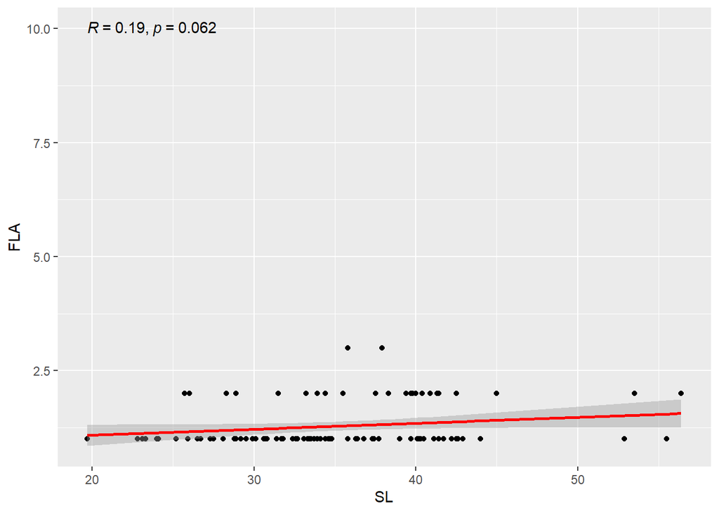

```r
reg.lat.FLA <- lm(lat1$FLA ~ lat1$SL)
reg.lat.FLA.plot <- ggplot(lat1, aes(x = SL, y = FLA)) +
  geom_point() +
  stat_smooth(method = "lm", col = "red") +
  stat_cor(label.y = 10)
reg.lat.FLA.plot
```

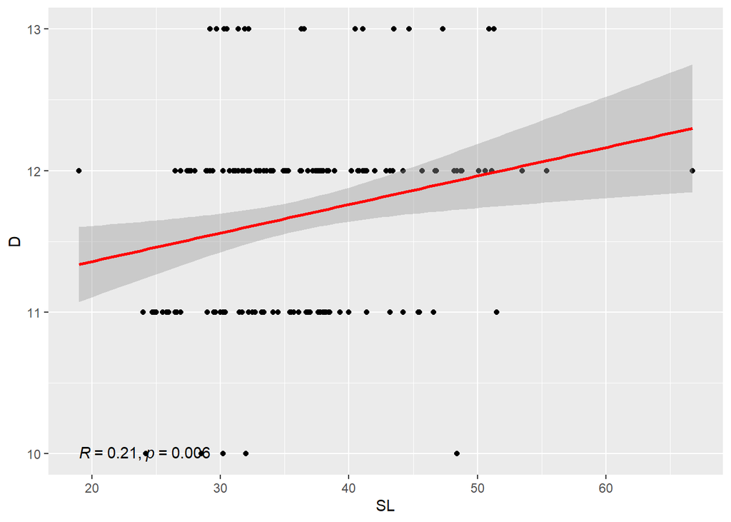

```r
reg.form.D1 <- lm(form1$D ~ form1$SL)
reg.form.D1.plot <- ggplot(form1, aes(x =SL, y = D)) +
  geom_point() +
  stat_smooth(method = "lm", col = "red") +
  stat_cor(label.y = 10)
reg.form.D1.plot
```

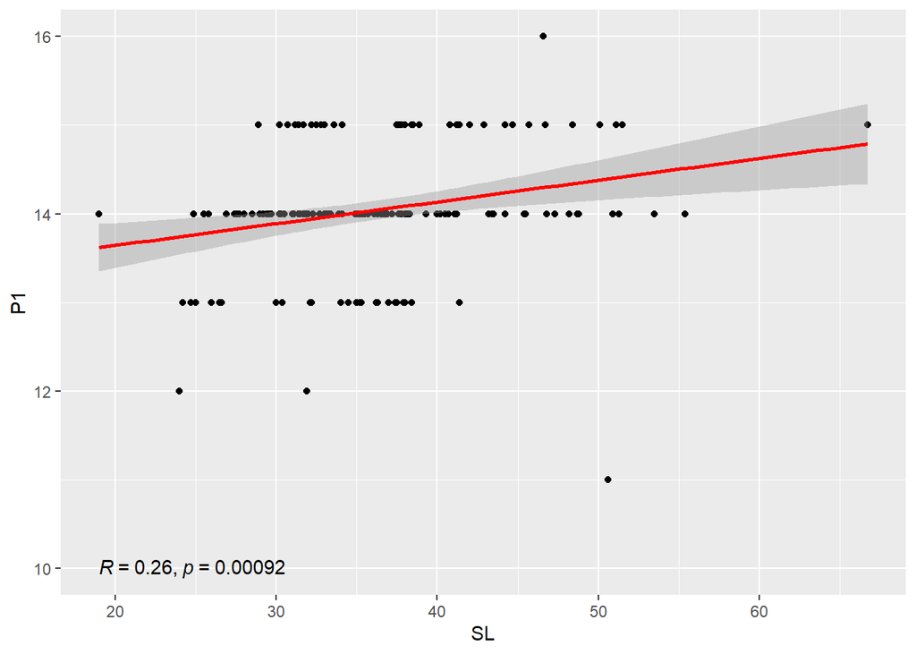

```r
reg.form.P11 <- lm(form1$P1 ~ form1$SL)
reg.form.P11.plot <- ggplot(form1, aes(x = SL, y = P1)) +
  geom_point() +
  stat_smooth(method = "lm", col = "red") +
  stat_cor(label.y = 10)
reg.form.P11.plot
```